# Factors determining average life expectancy.

Marcel Florjański, Filip Kasprzycki, Bartłomiej Klajn

2026-04-19

# 1. Introduction

In this project, we will analyze various factors in terms of their impact on life expectancy. Our dependent variable is: -life expectancy, and our explanatory variables are: -access to clean fuels and technologies for cooking, -children per woman, -gdp per capita, -share of adults defined as obese, -share of adults who smoke, -share of individuals using the internet, -share of the population with access to electocity.

## In this project we will consider 3 main hypotheses:

### H1: Economic development (measured by GDP per capita) has a positive and diminishing marginal impact on life expectancy.

### H2: Lifestyle risks, specifically smoking and obesity rates, are expected to have a significant negative impact on longevity.

### H3: Infrastructure indicators, such as access to electricity and clean fuels, are vital determinants, especially in developing nations.

All the data we use comes from Our World in Data, which is a reputable source for global statistics and research. The data is collected from various sources, including international organizations, research institutions, and government agencies. It is regularly updated and covers a wide range of topics, making it a valuable resource for our analysis of life expectancy and its determinants.

### Libraries we are going to use:

```r
library(tidyverse)
library(mice)
library(countrycode)
library(corrplot)
library(ggplot2)
library(car)
library(tseries)
library(lmtest)
```

# 2. Data Loading and Merging

In this section, we load the raw datasets and merge them based on country entity and code for the year 2022.

```r
# 1. Loading the Files
y_data   <- read_csv("life-expectancy.csv")
x_gdp    <- read_csv("gdp-per-capita-worldbank.csv")
x_fert   <- read_csv("children-per-woman-un.csv")
x_obese  <- read_csv("share-of-adults-defined-as-obese.csv")
x_smoke  <- read_csv("share-of-adults-who-smoke.csv")
x_net    <- read_csv("share-of-individuals-using-the-internet.csv")
x_elec   <- read_csv("share-of-the-population-with-access-to-electricity.csv")
x_fuel   <- read_csv("access-to-clean-fuels-and-technologies-for-cooking.csv")

# 2. Merging the datasets
df_final <- y_data %>%
  select(Entity, Code, LifeExp = 4) %>%
  inner_join(x_gdp %>% select(Code, GDP = 4), by = "Code") %>%
  inner_join(x_fert %>% select(Code, Fertility = 4), by = "Code") %>%
  inner_join(x_obese %>% select(Code, Obesity = 4), by = "Code") %>%
  inner_join(x_smoke %>% select(Code, Smoking = 4), by = "Code") %>%
  inner_join(x_net %>% select(Code, Internet = 4), by = "Code") %>%
  inner_join(x_elec %>% select(Code, Electricity = 4), by = "Code") %>%
  inner_join(x_fuel %>% select(Code, CleanFuels = 4), by = "Code") %>%
  drop_na()
# 3. Adding continent information using countrycode package
df_final$Continent <- countrycode(sourcevar = df_final$Code,
                                  origin = "iso3c",
                                  destination = "continent")

# 4. Converting char data to a factor variable
df_final$Continent <- as.factor(df_final$Continent)
df_final$Entity <- as.factor(df_final$Entity)
df_final$Code <- as.factor(df_final$Code)
table(df_final$Continent)
```

```
##
##   Africa Americas     Asia   Europe  Oceania
##       42       25       42       38       11
```

```r
# 5. Checking the final dataset
nrow(df_final)
```

```
## [1] 158
```

```r
head(df_final)
```

```
## # A tibble: 6 × 11
##   Entity     Code  LifeExp    GDP Fertility Obesity Smoking Internet Electricity
##   <fct>      <fct>   <dbl>  <dbl>     <dbl>   <dbl>   <dbl>    <dbl>       <dbl>
## 1 Afghanist… AFG      65.6  1982.      4.93    17.6    22.7     17.2        85.3
## 2 Albania    ALB      78.8 19389.      1.36    26.6    21.9     82.6       100
## 3 Algeria    DZA      76.1 14782.      2.82    24.2    21.2     74.8       100
## 4 Andorra    AND      84.0 63913.      1.07    20.5    36.3     94.5       100
## 5 Argentina  ARG      75.8 27825.      1.48    36.0    23.8     88.4       100
## 6 Armenia    ARM      74.6 17886.      1.72    27.9    24.9     77.0       100
## # ℹ 2 more variables: CleanFuels <dbl>, Continent <fct>
```

```r
md.pattern(df_final, plot = FALSE)
```

```
##  /\     /\
## {  `---'  }
## {  O   O  }
## ==>  V <==  No need for mice. This data set is completely observed.
##  \  \|/  /
##   `-----'
```

```
##     Entity Code LifeExp GDP Fertility Obesity Smoking Internet Electricity
## 158      1    1       1   1         1       1       1        1           1
##          0    0       0   0         0       0       0        0           0
##     CleanFuels Continent
## 158          1         1 0
##              0         0 0
```

# 3. Descriptive Statistics and Visualization

In this section, we will explore the descriptive statistics of our dataset.

At first, we will look at the summary statistics of our variables to understand their central tendencies and dispersions.

```r
summary(df_final %>% select(-Entity, -Code))
```

```
##     LifeExp           GDP           Fertility        Obesity
##  Min.   :54.08   Min.   :  1031   Min.   :0.780   Min.   : 2.082
##  1st Qu.:67.42   1st Qu.:  6292   1st Qu.:1.522   1st Qu.:12.188
##  Median :74.05   Median : 16369   Median :1.944   Median :23.778
##  Mean   :72.94   Mean   : 26763   Mean   :2.420   Mean   :23.443
##  3rd Qu.:78.26   3rd Qu.: 40424   3rd Qu.:3.179   3rd Qu.:31.257
##  Max.   :84.05   Max.   :133572   Max.   :6.215   Max.   :70.535
##     Smoking         Internet       Electricity       CleanFuels
##  Min.   : 3.30   Min.   : 11.00   Min.   : 10.30   Min.   :  0.20
##  1st Qu.:11.22   1st Qu.: 56.02   1st Qu.: 90.25   1st Qu.: 41.25
##  Median :19.55   Median : 78.78   Median :100.00   Median : 93.10
##  Mean   :19.77   Mean   : 70.02   Mean   : 87.61   Mean   : 71.28
##  3rd Qu.:26.77   3rd Qu.: 89.81   3rd Qu.:100.00   3rd Qu.:100.00
##  Max.   :48.30   Max.   :100.00   Max.   :100.00   Max.   :100.00
##     Continent
##  Africa  :42
##  Americas:25
##  Asia    :42
##  Europe  :38
##  Oceania :11
##
```

Next, we will visualize the structure of our variables.

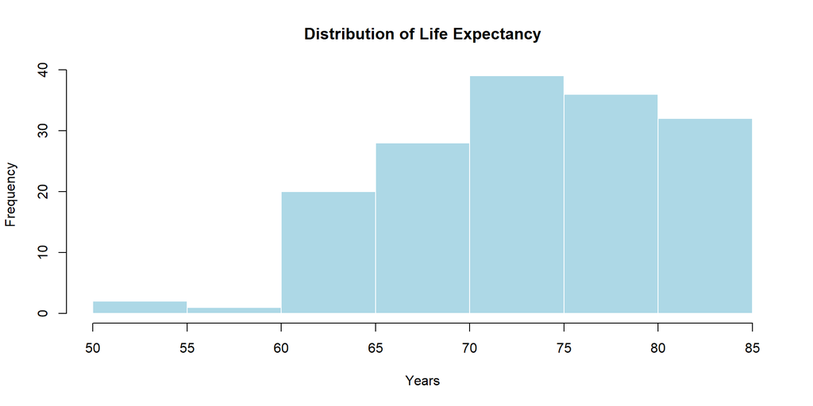

```r
hist(df_final$LifeExp, main="Distribution of Life Expectancy", col="lightblue", border="white", xlab="Years")
```

The distribution of life expectancy is slightly skewed to the left, but is strongly concentrated around the ages of 70-80. No outliers.

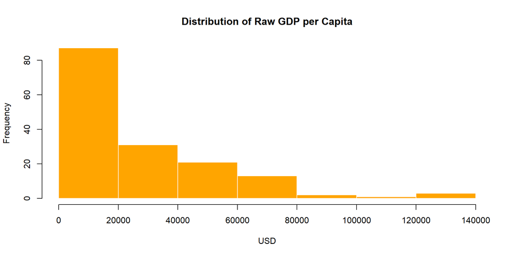

```r
hist(df_final$GDP, main="Distribution of Raw GDP per Capita", col="orange", border="white", xlab="USD")
```

The distribution is very skewed to the right. Most countries have rather low scores (below 20,000 USD), but there are a few that reach over 100,000 USD. For correct modeling, it is advisable to take the logarithm.

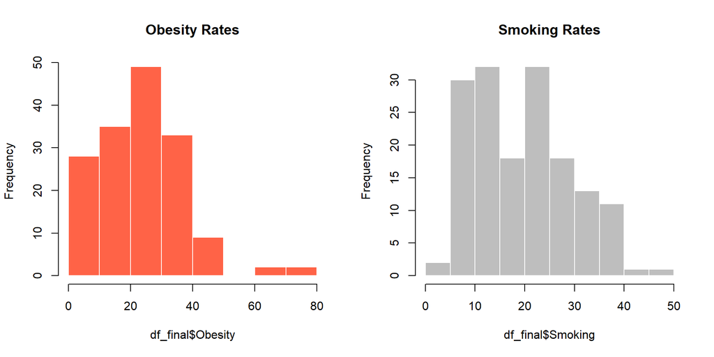

```r
par(mfrow=c(1,2))
hist(df_final$Obesity, main="Obesity Rates", col="tomato", border="white")
hist(df_final$Smoking, main="Smoking Rates", col="grey", border="white")
```

```r
par(mfrow=c(1,1))
```

Obesity has a distribution close to normal. Tobacco has a fairly even distribution with a slight right-skew.

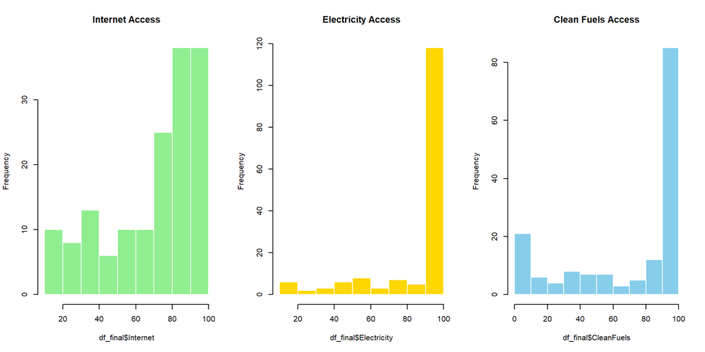

```r
par(mfrow=c(1,3))
hist(df_final$Internet, main="Internet Access", col="lightgreen", border="white")
hist(df_final$Electricity, main="Electricity Access", col="gold", border="white")
hist(df_final$CleanFuels, main="Clean Fuels Access", col="skyblue", border="white")
```

```r
par(mfrow=c(1,1))
```

Infrastructure variables are highly specific, with a large number of countries scoring close to 100%. This may suggest collinearity between these variables and GDP levels.

Based on the previous histogram analysis, we apply a natural logarithm to GDP per capita. This transformation is intended to linearize the relationship between income and life expectancy, as suggested by Hypothesis 1.

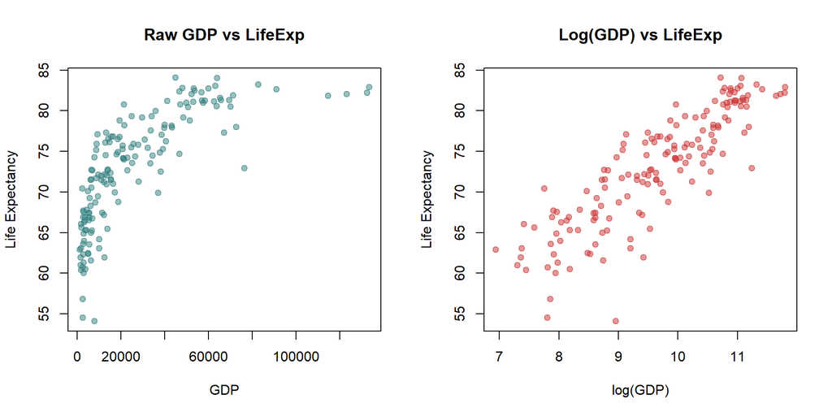

```r
df_final$log_GDP <- log(df_final$GDP)


par(mfrow=c(1,2))
plot(df_final$GDP, df_final$LifeExp, main="Raw GDP vs LifeExp",
     xlab="GDP", ylab="Life Expectancy", pch=19, col=rgb(0.2,0.5,0.5,0.5))
plot(df_final$log_GDP, df_final$LifeExp, main="Log(GDP) vs LifeExp",
     xlab="log(GDP)", ylab="Life Expectancy", pch=19, col=rgb(0.8,0.2,0.2,0.5))
```

```r
par(mfrow=c(1,1))
```

After analyzing the graphs, the assumption is confirmed: the relationship between GDP and life expectancy is nonlinear. The effect of diminishing returns is visible: in low-income countries, each additional dollar significantly increases life expectancy, but in wealthy countries, this effect disappears. Using the logarithm “straightened” the graph. For further analysis, we will use the logarithm variable.

Next, we will look at the correlation matrix to understand the relationships between our variables.

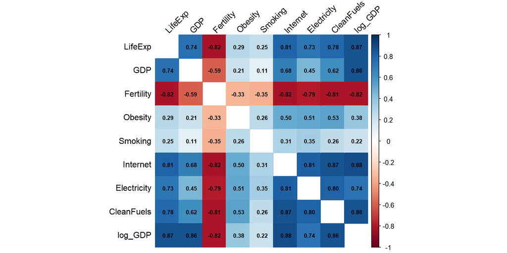

```r
numeric_data <- df_final %>% select(where(is.numeric))

M <- cor(numeric_data)

corrplot(M,
         method = "color",
         addCoef.col = "black",
         number.cex = 0.7,
         tl.col = "black",
         tl.srt = 45,
         diag = FALSE)
```

The correlation matrix confirms the improved effectiveness of the GDP variable by taking it into logarithms – an increase from 0.74 to 0.87. An interesting relationship is the number of children a woman bears and life expectancy – having many children indicates a shorter lifespan, but this is most likely conditioned by the socio-economic situation – having many children is most common in developing countries, where people statistically have shorter lifespans. However, the matrix revealed a strong correlation between the infrastructure variables (both among themselves and in relation to GDP). This may indicate collinearity. This compels us to conduct detailed analysis in this area in the future, particularly the use of VIF in the modeling stage.

At the end for this section we are going to analyze how life expectancy varies across continents.

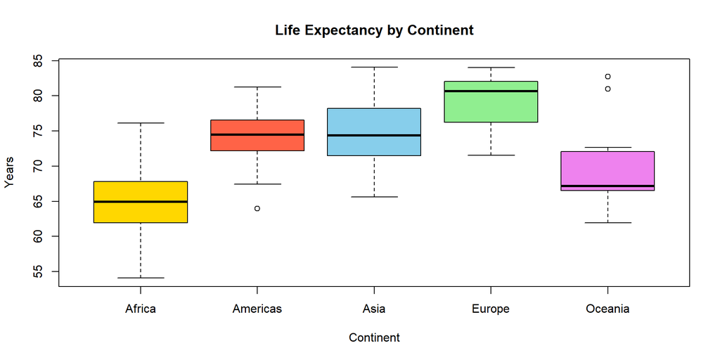

```r
boxplot(LifeExp ~ Continent, data = df_final,
        col = c("gold", "tomato", "skyblue", "lightgreen", "violet"),
        main = "Life Expectancy by Continent",
        ylab = "Years", xlab = "Continent")
```

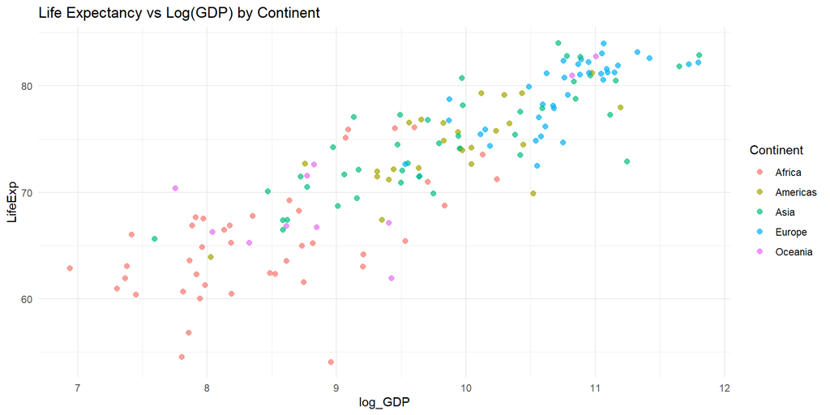

```r
ggplot(df_final, aes(x = log_GDP, y = LifeExp, color = Continent)) +
  geom_point(alpha = 0.7, size = 2) +
  theme_minimal() +
  labs(title = "Life Expectancy vs Log(GDP) by Continent")
```

## Model preparation- Train/Test split

After the initial analysis of variables, we divide the data into two sets - we will train our model on one set, and then test its effectiveness on the “new” one. We divide the data in an 80/20 ratio.

```r
set.seed(123)

train_indices <- sample(1:nrow(df_final), size = 0.8 * nrow(df_final))

train_data <- df_final[train_indices, ]
test_data  <- df_final[-train_indices, ]

cat("Training set size:", nrow(train_data), "\n")
```

```
## Training set size: 126
```

```r
cat("Testing set size: ", nrow(test_data))
```

```
## Testing set size:  32
```

Now let’s choose the optimal set of variables, for this task we will use a Hellwig method, which evaluates the explanatory power of each variable in relation to the dependent variable and the redundancy among the explanatory variables. The method calculates a “quality index” for each variable, which helps us identify which variables contribute most to explaining the variance in life expectancy while minimizing redundancy.

```r
# Calculate the correlation matrix for the numeric variables in the training dataset, the factorial varaibles will be includes in the model as countries definitely have impact on the life expectancy.

numeric_data <- train_data %>% select(where(is.numeric), -GDP) # usuwamy surowe GDP, zostawiamy log_GDP

cor_matrix <- cor(numeric_data)

r0 <- cor_matrix["LifeExp", -which(colnames(cor_matrix) == "LifeExp")]
r <-cor_matrix[-which(rownames(cor_matrix) == "LifeExp"), -which(colnames(cor_matrix) == "LifeExp")]

scenarios <- expand.grid(rep(list(c(TRUE, FALSE)), ncol(r) ))
H_final<-c()

for(i in 1:nrow(scenarios) ) {
  indices<-which(as.logical(scenarios[i,]))
  if(length(indices)==0) {
    H_final[i]<-0
    next
  }
  H<-c()
  for(j in 1:length(indices)) {
     H[j]<- r0[indices[j]]^2 / sum(abs(r[indices[j],indices]))
  }
  H_final[i]<-sum(H)
}


best_idx <- which.max(H_final)

best_vars <- colnames(r)[as.logical(scenarios[best_idx, ])]
```

## Now let’s see the best dataset for our model.

```r
print(best_vars)
```

```
## [1] "Fertility" "log_GDP"
```

# 4. Model Estimation and Comparison

We decided to compare two approaches: a parsimonious model suggested by the Hellwig method and a full research model that includes all hypothesized predictors.

```r
# Model 1: Based on Hellwig's selection + factors as country
model_hellwig <- lm(LifeExp ~ log_GDP + Fertility + Continent, data = train_data)

# Model 2: Full research model (including lifestyle and continents)
# We exclude raw GDP to avoid perfect collinearity with log_GDP
model_full <- lm(LifeExp ~ log_GDP + Fertility + Obesity + Smoking +
                 Internet + Electricity + CleanFuels + Continent,
                 data = train_data)

# Reviewing results
summary(model_hellwig)
```

```
##
## Call:
## lm(formula = LifeExp ~ log_GDP + Fertility + Continent, data = train_data)
##
## Residuals:
##     Min      1Q  Median      3Q     Max
## -11.168  -1.842   0.060   2.035   6.710
##
## Coefficients:
##                   Estimate Std. Error t value Pr(>|t|)
## (Intercept)        47.6598     5.0837   9.375 5.66e-16 ***
## log_GDP             2.9994     0.4499   6.667 8.60e-10 ***
## Fertility          -2.0377     0.4397  -4.635 9.23e-06 ***
## ContinentAmericas   0.5252     1.1684   0.450   0.6539
## ContinentAsia       2.0900     0.9965   2.097   0.0381 *
## ContinentEurope     2.3998     1.2078   1.987   0.0492 *
## ContinentOceania    0.8992     1.1942   0.753   0.4529
## ---
## Signif. codes:  0 '***' 0.001 '**' 0.01 '*' 0.05 '.' 0.1 ' ' 1
##
## Residual standard error: 3.149 on 119 degrees of freedom
## Multiple R-squared:  0.8207, Adjusted R-squared:  0.8116
## F-statistic: 90.76 on 6 and 119 DF,  p-value: < 2.2e-16
```

```r
summary(model_full)
```

```
##
## Call:
## lm(formula = LifeExp ~ log_GDP + Fertility + Obesity + Smoking +
##     Internet + Electricity + CleanFuels + Continent, data = train_data)
##
## Residuals:
##      Min       1Q   Median       3Q      Max
## -11.5749  -1.8961   0.2731   2.1761   6.5013
##
## Coefficients:
##                   Estimate Std. Error t value Pr(>|t|)
## (Intercept)       50.41180    6.53887   7.710 5.14e-12 ***
## log_GDP            2.58416    0.69458   3.720 0.000310 ***
## Fertility         -1.86587    0.53574  -3.483 0.000705 ***
## Obesity           -0.07148    0.03632  -1.968 0.051498 .
## Smoking           -0.05850    0.04236  -1.381 0.170002
## Internet           0.01554    0.02841   0.547 0.585400
## Electricity        0.01029    0.02479   0.415 0.678832
## CleanFuels         0.01441    0.02078   0.694 0.489398
## ContinentAmericas  1.21903    1.25126   0.974 0.331998
## ContinentAsia      2.48740    1.14410   2.174 0.031764 *
## ContinentEurope    3.31894    1.36512   2.431 0.016605 *
## ContinentOceania   3.52349    1.59535   2.209 0.029202 *
## ---
## Signif. codes:  0 '***' 0.001 '**' 0.01 '*' 0.05 '.' 0.1 ' ' 1
##
## Residual standard error: 3.119 on 114 degrees of freedom
## Multiple R-squared:  0.8314, Adjusted R-squared:  0.8152
## F-statistic: 51.12 on 11 and 114 DF,  p-value: < 2.2e-16
```

The initial estimation of the full model yields a high Adjusted R-squared (0.8152), indicating that our variables collectively explain about 81.5% of the variance in global life expectancy. As expected, log_GDP and Fertility are highly significant ($p < 0.001$), and the Continent dummy variables confirm significant regional differences (e.g., a strong positive effect for Europe and Oceania compared to the African baseline). However, the infrastructure variables (Internet, Electricity, CleanFuels) and lifestyle factors (Smoking, Obesity) lack statistical significance. In econometric modeling, such a scenario—where the overall model fit is high but individual predictors are insignificant—strongly suggests the presence of multicollinearity. To diagnose this, we must examine the Variance Inflation Factor (VIF).

```r
vif(model_full)
```

```
##                  GVIF Df GVIF^(1/(2*Df))
## log_GDP      8.730664  1        2.954770
## Fertility    5.805084  1        2.409374
## Obesity      3.085865  1        1.756663
## Smoking      2.143831  1        1.464183
## Internet     7.225386  1        2.688008
## Electricity  4.563562  1        2.136250
## CleanFuels   7.395587  1        2.719483
## Continent   10.497359  4        1.341637
```

The VIF diagnostic test clearly explains the lack of significance in our previous model. The VIF values for log_GDP (8.73), CleanFuels (7.40), and Internet (7.23) severely exceed the standard acceptable threshold of 5, indicating extreme multicollinearity. Access to electricity, internet, and clean fuels is so strongly coupled with a country’s wealth that including them alongside GDP artificially inflates the standard errors of our estimators.

From a scientific standpoint, this compels us to reject Hypothesis 3 (H3): at the macroeconomic level, basic infrastructure does not act as an independent driver of longevity, but is rather a direct function of economic development (log_GDP). Consequently, to establish a robust and mathematically sound model, we will remove the redundant infrastructure variables (Internet, Electricity, CleanFuels) and estimate a reduced model. This will allow us to properly test our remaining hypotheses (H1 and H2) without the distortion of variance inflation.

```r
model_final <- lm(LifeExp ~ log_GDP + Fertility + Obesity + Smoking +
                Continent,
                 data = train_data)

# Reviewing results

summary(model_final)
```

```
##
## Call:
## lm(formula = LifeExp ~ log_GDP + Fertility + Obesity + Smoking +
##     Continent, data = train_data)
##
## Residuals:
##      Min       1Q   Median       3Q      Max
## -11.7478  -1.8738   0.2426   2.0251   6.8646
##
## Coefficients:
##                   Estimate Std. Error t value Pr(>|t|)
## (Intercept)       49.23770    5.78456   8.512 6.68e-14 ***
## log_GDP            3.04257    0.51236   5.938 3.02e-08 ***
## Fertility         -2.18485    0.45795  -4.771 5.34e-06 ***
## Obesity           -0.04774    0.02980  -1.602   0.1118
## Smoking           -0.05956    0.04203  -1.417   0.1591
## ContinentAmericas  1.15767    1.21341   0.954   0.3420
## ContinentAsia      2.65668    1.05372   2.521   0.0130 *
## ContinentEurope    3.31101    1.33336   2.483   0.0144 *
## ContinentOceania   3.30428    1.53400   2.154   0.0333 *
## ---
## Signif. codes:  0 '***' 0.001 '**' 0.01 '*' 0.05 '.' 0.1 ' ' 1
##
## Residual standard error: 3.098 on 117 degrees of freedom
## Multiple R-squared:  0.8293, Adjusted R-squared:  0.8177
## F-statistic: 71.07 on 8 and 117 DF,  p-value: < 2.2e-16
```

# 5. Model Diagnostics

Now let’s focus on the model, and see whether there is a need to apply some changes or not.

```r
bptest(model_final)
```

```
##
##  studentized Breusch-Pagan test
##
## data:  model_final
## BP = 9.6228, df = 8, p-value = 0.2925
```

```r
resettest(model_final, power = 2:3, type = "fitted")
```

```
##
##  RESET test
##
## data:  model_final
## RESET = 4.7387, df1 = 2, df2 = 115, p-value = 0.01053
```

```r
jarque.bera.test(residuals(model_final))
```

```
##
##  Jarque Bera Test
##
## data:  residuals(model_final)
## X-squared = 14.723, df = 2, p-value = 0.0006351
```

As we can see the p-value in RESET test is significanly belov thereshold 0,05, now we will try to implement different models and see if there is a chance for an improvement

```r
model_final1 <- lm(log(LifeExp) ~ log_GDP + Fertility + Obesity + Smoking +
                Continent,
                 data = train_data)


model_final2 <- lm(LifeExp ~ log_GDP + log(Fertility) + log(Obesity) + log(Smoking) +
                Continent,
                 data = train_data)

model_final3 <- lm(LifeExp ~ I(log_GDP^2) + Fertility + Obesity + Smoking +
                 Continent,
                 data = train_data)

resettest(model_final1, power = 2:3, type = "fitted")
```

```
##
##  RESET test
##
## data:  model_final1
## RESET = 2.6948, df1 = 2, df2 = 115, p-value = 0.07182
```

```r
bptest(model_final1)
```

```
##
##  studentized Breusch-Pagan test
##
## data:  model_final1
## BP = 11.485, df = 8, p-value = 0.1757
```

```r
jarque.bera.test(residuals(model_final1))
```

```
##
##  Jarque Bera Test
##
## data:  residuals(model_final1)
## X-squared = 45.003, df = 2, p-value = 1.689e-10
```

```r
resettest(model_final2, power = 2:3, type = "fitted")
```

```
##
##  RESET test
##
## data:  model_final2
## RESET = 1.2515, df1 = 2, df2 = 115, p-value = 0.29
```

```r
bptest(model_final2)
```

```
##
##  studentized Breusch-Pagan test
##
## data:  model_final2
## BP = 11.858, df = 8, p-value = 0.1577
```

```r
jarque.bera.test(residuals(model_final2))
```

```
##
##  Jarque Bera Test
##
## data:  residuals(model_final2)
## X-squared = 14.393, df = 2, p-value = 0.0007492
```

```r
resettest(model_final3, power = 2:3, type = "fitted")
```

```
##
##  RESET test
##
## data:  model_final3
## RESET = 3.0804, df1 = 2, df2 = 115, p-value = 0.04975
```

```r
bptest(model_final3)
```

```
##
##  studentized Breusch-Pagan test
##
## data:  model_final3
## BP = 9.0696, df = 8, p-value = 0.3365
```

```r
jarque.bera.test(residuals(model_final3))
```

```
##
##  Jarque Bera Test
##
## data:  residuals(model_final3)
## X-squared = 15.192, df = 2, p-value = 0.0005026
```

```r
resettest(model_hellwig, power = 2:3, type = "fitted")
```

```
##
##  RESET test
##
## data:  model_hellwig
## RESET = 5.7518, df1 = 2, df2 = 117, p-value = 0.004143
```

```r
bptest(model_hellwig)
```

```
##
##  studentized Breusch-Pagan test
##
## data:  model_hellwig
## BP = 10.476, df = 6, p-value = 0.106
```

```r
jarque.bera.test(residuals(model_hellwig))
```

```
##
##  Jarque Bera Test
##
## data:  residuals(model_hellwig)
## X-squared = 12.011, df = 2, p-value = 0.002465
```

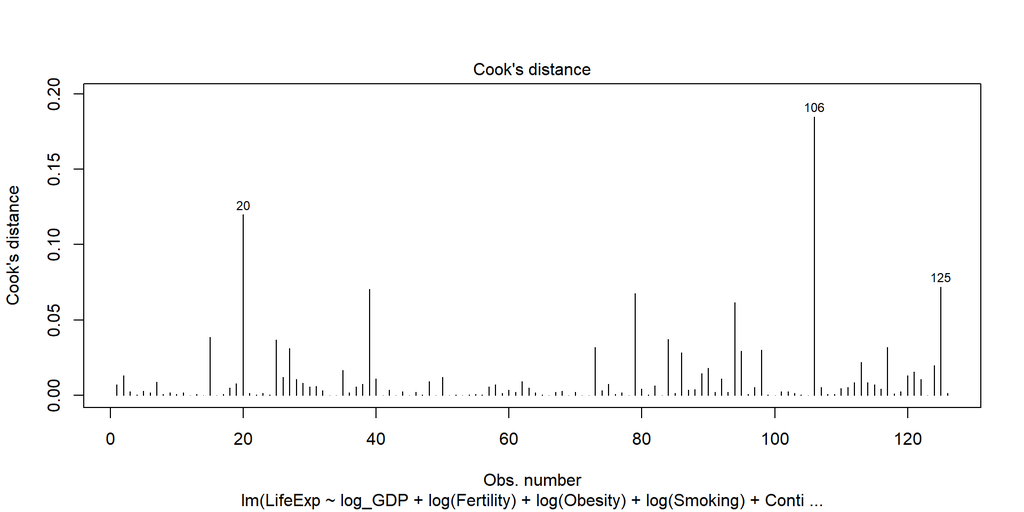

```r
plot(model_final2, which = 4)
```

```r
train_data[c(20, 106, 125), ]
```

```
## # A tibble: 3 × 12
##   Entity  Code  LifeExp    GDP Fertility Obesity Smoking Internet Electricity
##   <fct>   <fct>   <dbl>  <dbl>     <dbl>   <dbl>   <dbl>    <dbl>       <dbl>
## 1 Nauru   NRU      61.9 12364.      3.38    70.2    48.3     81.7       100
## 2 Nigeria NGA      54.1  7752.      4.55    10.8     3.3     37.7        60.5
## 3 Lesotho LSO      56.8  2578.      2.72    19.3    24.3     46.5        50
## # ℹ 3 more variables: CleanFuels <dbl>, Continent <fct>, log_GDP <dbl>
```

```r
model_no_outliers <- lm(LifeExp ~ log_GDP + log(Fertility) + log(Obesity) + log(Smoking) + Continent,
                        data = train_data[-c(20, 106, 125), ])

jarque.bera.test(residuals(model_no_outliers))
```

```
##
##  Jarque Bera Test
##
## data:  residuals(model_no_outliers)
## X-squared = 0.77534, df = 2, p-value = 0.6786
```

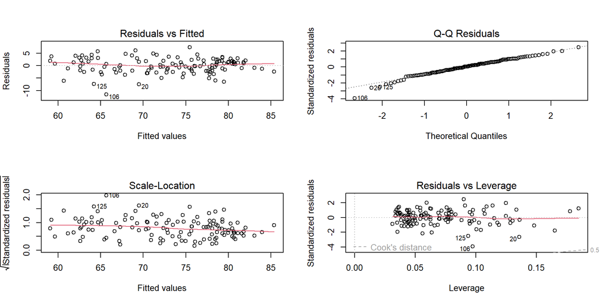

```r
par(mfrow = c(2, 2)) # Dzieli okno graficzne na 4 części
plot(model_final2)
```

```r
summary(model_final2)
```

```
##
## Call:
## lm(formula = LifeExp ~ log_GDP + log(Fertility) + log(Obesity) +
##     log(Smoking) + Continent, data = train_data)
##
## Residuals:
##      Min       1Q   Median       3Q      Max
## -11.5892  -1.8831   0.1767   1.9147   7.3555
##
## Coefficients:
##                   Estimate Std. Error t value Pr(>|t|)
## (Intercept)       46.76721    5.82805   8.025 8.81e-13 ***
## log_GDP            3.25280    0.51717   6.290 5.70e-09 ***
## log(Fertility)    -5.39045    1.18397  -4.553 1.30e-05 ***
## log(Obesity)      -0.81765    0.54904  -1.489   0.1391
## log(Smoking)      -0.09408    0.69507  -0.135   0.8926
## ContinentAmericas  1.38884    1.17254   1.184   0.2386
## ContinentAsia      2.29024    1.04917   2.183   0.0310 *
## ContinentEurope    2.44205    1.30854   1.866   0.0645 .
## ContinentOceania   2.47701    1.41789   1.747   0.0833 .
## ---
## Signif. codes:  0 '***' 0.001 '**' 0.01 '*' 0.05 '.' 0.1 ' ' 1
##
## Residual standard error: 3.107 on 117 degrees of freedom
## Multiple R-squared:  0.8283, Adjusted R-squared:  0.8166
## F-statistic: 70.56 on 8 and 117 DF,  p-value: < 2.2e-16
```

## Justification for Removing Outliers

Based on the Cook’s distance plot presented above, several observations were identified as highly influential in the estimation of the regression model.

In particular, observations with indices 20, 106, and 125 exhibit significantly higher Cook’s distance values compared to the rest of the sample. This indicates that these data points have a disproportionately large impact on the estimated coefficients.

A closer inspection reveals that these observations correspond to countries with extreme socio-economic characteristics:

- **Nauru** – exceptionally high obesity and smoking rates,
- **Nigeria** – very high fertility rate and relatively low life expectancy,
- **Lesotho** – unusually low life expectancy given its explanatory variables.

Such observations may violate the standard assumptions of the linear regression model and distort the estimation results by exerting excessive influence on parameter values.

From an econometric perspective, it is justified to temporarily remove these outliers in order to:

- reduce the impact of high-leverage observations,
- improve the distributional properties of residuals,
- assess the robustness of the model.

After removing these observations, the Jarque-Bera test indicates no significant deviation from normality (p-value = 0.6786), which confirms a substantial improvement in model adequacy.

It should be emphasized that the removal of outliers serves as a robustness check rather than a permanent exclusion of data from the analysis.

# 6. Prediction and Error Analysis

In this section, we evaluate the predictive performance of our model using the test dataset. We calculate standard error metrics such as MAE, RMSE, and MAPE.

```r
predicted<-predict(model_final2, newdata=test_data)
test_residuals<-predicted - test_data$LifeExp
MAE<-mean(abs(test_residuals))
RMSE<-sqrt(mean(test_residuals^2))
MAE
```

```
## [1] 2.860335
```

```r
RMSE
```

```
## [1] 3.402801
```

```r
MAPE <- mean(abs(test_residuals / test_data$LifeExp)) * 100
MAPE
```

```
## [1] 4.007013
```

```r
##############################################################
model_hellwig
```

```
##
## Call:
## lm(formula = LifeExp ~ log_GDP + Fertility + Continent, data = train_data)
##
## Coefficients:
##       (Intercept)            log_GDP          Fertility  ContinentAmericas
##           47.6598             2.9994            -2.0377             0.5252
##     ContinentAsia    ContinentEurope   ContinentOceania
##            2.0900             2.3998             0.8992
```

```r
predicted<-predict(model_hellwig, newdata=test_data)
test_residuals<-predicted - test_data$LifeExp
MAE<-mean(abs(test_residuals))
RMSE<-sqrt(mean(test_residuals^2))
MAE
```

```
## [1] 2.81403
```

```r
RMSE
```

```
## [1] 3.383299
```

```r
MAPE <- mean(abs(test_residuals / test_data$LifeExp)) * 100
MAPE
```

```
## [1] 3.961343
```

# 7. Summary and Interpretation

This study aimed to identify the key determinants of life expectancy across countries using cross-sectional data for 2022. The analysis combined economic, lifestyle, and infrastructure variables to test three main hypotheses regarding the drivers of longevity.

## Model Comparison and Final Choice

Based on both diagnostic tests and predictive performance, we compare the Hellwig model and the extended model (model_final2).

From the diagnostic perspective:

- The Breusch–Pagan test indicates no heteroskedasticity in both models (p-values > 0.05).
- However, the RESET test suggests misspecification in the Hellwig model (p-value = 0.004), while model_final2 does not show this issue (p-value = 0.29).
- The Jarque–Bera test indicates non-normality of residuals in both models, although this problem is mitigated after removing outliers.

From the predictive performance perspective:

model_final2:

- MAE = 2.86
- RMSE = 3.40
- MAPE = 4.01%

Hellwig model:

- MAE = 2.81
- RMSE = 3.38
- MAPE = 3.96%

Although the Hellwig model achieves slightly better predictive accuracy, the differences are very small.

## Final Conclusion – Preferred Model

Taking into account both statistical diagnostics and theoretical considerations, model_final2 is selected as the better model.

Despite slightly worse predictive performance, model_final2 does not suffer from functional form misspecification (RESET test), unlike the Hellwig model. This means that it more accurately captures the underlying relationships between variables.

Additionally, model_final2 includes theoretically justified variables (such as lifestyle factors in logarithmic form), which improves its interpretability and consistency with economic theory.

In contrast, the Hellwig model, although simpler and slightly more accurate in prediction, is misspecified and therefore less reliable for inference.

## Parameter Interpretation (model_final2)

### log_GDP:

The estimated coefficient is 3.25. This means that, ceteris paribus, a 10% increase in GDP per capita is associated with an increase in average life expectancy by approximately 0.325 years (roughly 4 months). This strongly confirms our first hypothesis regarding the diminishing marginal utility of economic growth.

### log(Fertility):

The estimated coefficient is -5.39. Assuming other conditions remain constant, a 10% increase in the fertility rate is associated with a decrease in life expectancy by approximately 0.539 years (roughly 6.5 months).

### Continent (Dummy Variables):

The categorical variables show regional fixed effects relative to the baseline continent (Africa). For instance, the coefficient for Europe is 2.44. This signifies that, ceteris paribus, a country located in Europe has an average life expectancy that is 2.44 years longer than a country in Africa with the exact same GDP, fertility, and lifestyle factors. Similarly, being in Asia adds 2.29 years compared to the African baseline.

### Lifestyle Factors (Obesity and Smoking):

Although the coefficients for log(Obesity) (-0.81) and log(Smoking) (-0.09) are negative—which aligns with the theoretical assumptions of H2—their high p-values (0.139 and 0.892, respectively) indicate that they are not statistically significant in this model.

## Overall Interpretation

- H1 (economic development): confirmed  
  GDP per capita (in logarithmic form) has a strong positive impact on life expectancy, with diminishing marginal effects.
- H2 (lifestyle factors): NOT CONFIRMED  
  Although obesity and smoking show negative coefficients as expected, they are statistically insignificant (p > 0.05), so we cannot confirm their impact on life expectancy.
- H3 (infrastructure): rejected Infrastructure variables are not significant once GDP is included, suggesting that their impact is largely captured by economic development.